# analysisscript2

Ehsan

10/20/2021

# Libraries

```r
library(tidyverse)
library(tidymodels)
library(dplyr)
library(here)
```

#Load data

```r
data_location <- here::here("data","processed_data","processeddata.rds")
```

```r
data <- readRDS(data_location)
```

#set seed for random numbers

```r
set.seed(222)
```

#put 3/4 of data into the training set

```r
split_data <- initial_split(data, prop = 3/4)
```

# create two dataframe: test and training

```r
training_data <- training(split_data)
test_data  <- testing(split_data)
```

#Create a simple recipe that fits categorical outcome of interest (Nausea) to all predictors.

```r
nausea_recipe <- recipe(Nausea ~., data = training_data)
```

#path for logistic regression model

```r
lg_mod <- logistic_reg() %>%
  set_engine("glm")
```

#create workflow, add model type and the recipe

```r
Nausea_workflow <-
  workflow() %>%
  add_model(lg_mod) %>%
  add_recipe(nausea_recipe)
```

#model fitting to training data

```r
Nausea_fit <-
  Nausea_workflow %>%
  fit(data = training_data)
```

#how it looks

```r
Nausea_fit %>%
  extract_fit_parsnip() %>%
  tidy()
```

```
## # A tibble: 38 × 5
##    term                 estimate std.error statistic p.value
##    <chr>                   <dbl>     <dbl>     <dbl>   <dbl>
##  1 (Intercept)             1.63      9.40      0.173  0.862
##  2 SwollenLymphNodesYes   -0.241     0.232    -1.04   0.298
##  3 ChestCongestionYes      0.219     0.257     0.853  0.394
##  4 ChillsSweatsYes         0.115     0.332     0.346  0.729
##  5 NasalCongestionYes      0.560     0.311     1.80   0.0713
##  6 CoughYNYes             -0.705     0.611    -1.15   0.249
##  7 SneezeYes               0.117     0.248     0.473  0.636
##  8 FatigueYes              0.177     0.438     0.403  0.687
##  9 SubjectiveFeverYes      0.229     0.264     0.868  0.385
## 10 HeadacheYes             0.435     0.352     1.24   0.216
## # … with 28 more rows
```

#applying oit to make some predictions on test data

```r
predict(Nausea_fit, test_data)
```

```
## # A tibble: 183 × 1
##    .pred_class
##    <fct>
##  1 No
##  2 No
##  3 No
##  4 No
##  5 No
##  6 Yes
##  7 Yes
##  8 No
##  9 No
## 10 Yes
## # … with 173 more rows
```

#more prediction using augment.

```r
Nausea_augment_predict <-
  augment(Nausea_fit, test_data)
```

#evaluate ROC and ROC_auc to see how good it fits the data

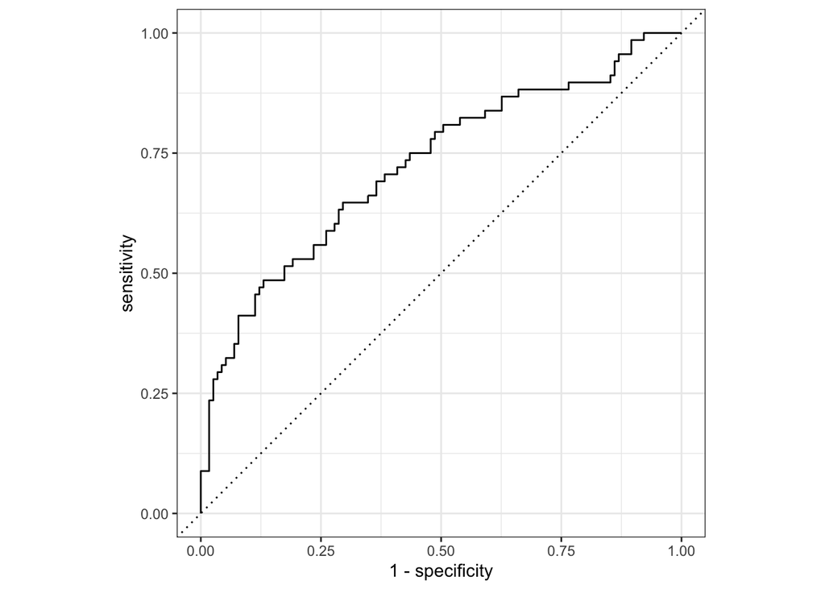

```r
Nausea_augment_predict %>%
  roc_curve(truth = Nausea, .pred_Yes, event_level = "second") %>%
  autoplot()
```

```r
Nausea_augment_predict %>%
  roc_auc(truth = Nausea, .pred_Yes, event_level = "second")
```

```
## # A tibble: 1 × 3
##   .metric .estimator .estimate
##   <chr>   <chr>          <dbl>
## 1 roc_auc binary         0.724
```

#roc_auc value is 0.72, which is good.

#predict, augment, ROC-curve, roc_auc for the training data this time

```r
predict(Nausea_fit, training_data)
```

```
## # A tibble: 547 × 1
##    .pred_class
##    <fct>
##  1 No
##  2 Yes
##  3 No
##  4 No
##  5 Yes
##  6 No
##  7 No
##  8 No
##  9 No
## 10 No
## # … with 537 more rows
```

```r
Nausea_augment_predict1 <-
  augment(Nausea_fit, training_data)
```

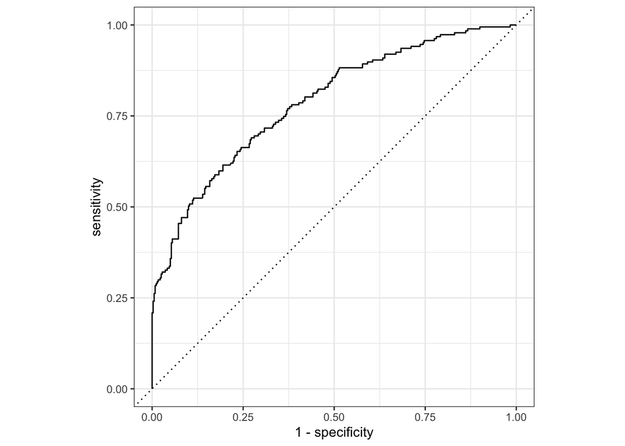

```r
Nausea_augment_predict1 %>%
  roc_curve(truth = Nausea, .pred_Yes, event_level = "second") %>%
  autoplot()
```

```r
Nausea_augment_predict1 %>%
  roc_auc(truth = Nausea, .pred_Yes, event_level = "second")
```

```
## # A tibble: 1 × 3
##   .metric .estimator .estimate
##   <chr>   <chr>          <dbl>
## 1 roc_auc binary         0.787
```

#roc_auc value is 0.78, which is good.

#Alternative model using just the main predictor: runny nose. Making recipe

```r
nausea_rec_Alt <- recipes::recipe(Nausea ~ RunnyNose, data = training_data)
```

```r
lg_mod <- logistic_reg() %>%
  set_engine("glm")
```

#creating workflow with the alternative recipe

```r
Nausea_Alt_workflow <-
  workflow() %>%
  add_model(lg_mod) %>%
  add_recipe(nausea_rec_Alt)
```

#fit it to training data

```r
Nausea_fit2 <-
  Nausea_Alt_workflow %>%
  fit(data = training_data)
```

#see how it looks

```r
Nausea_fit2 %>%
  extract_fit_parsnip() %>%
  tidy()
```

```
## # A tibble: 2 × 5
##   term         estimate std.error statistic    p.value
##   <chr>           <dbl>     <dbl>     <dbl>      <dbl>
## 1 (Intercept)    -0.790     0.172    -4.59  0.00000447
## 2 RunnyNoseYes    0.188     0.202     0.930 0.352
```

#prediction from test data

```r
predict(Nausea_fit2, test_data)
```

```
## # A tibble: 183 × 1
##    .pred_class
##    <fct>
##  1 No
##  2 No
##  3 No
##  4 No
##  5 No
##  6 No
##  7 No
##  8 No
##  9 No
## 10 No
## # … with 173 more rows
```

#prediction + augment from test data

```r
Nausea_augment_predict3 <-
  augment(Nausea_fit2, test_data)
```

#roc_curve and roc_auc from test data

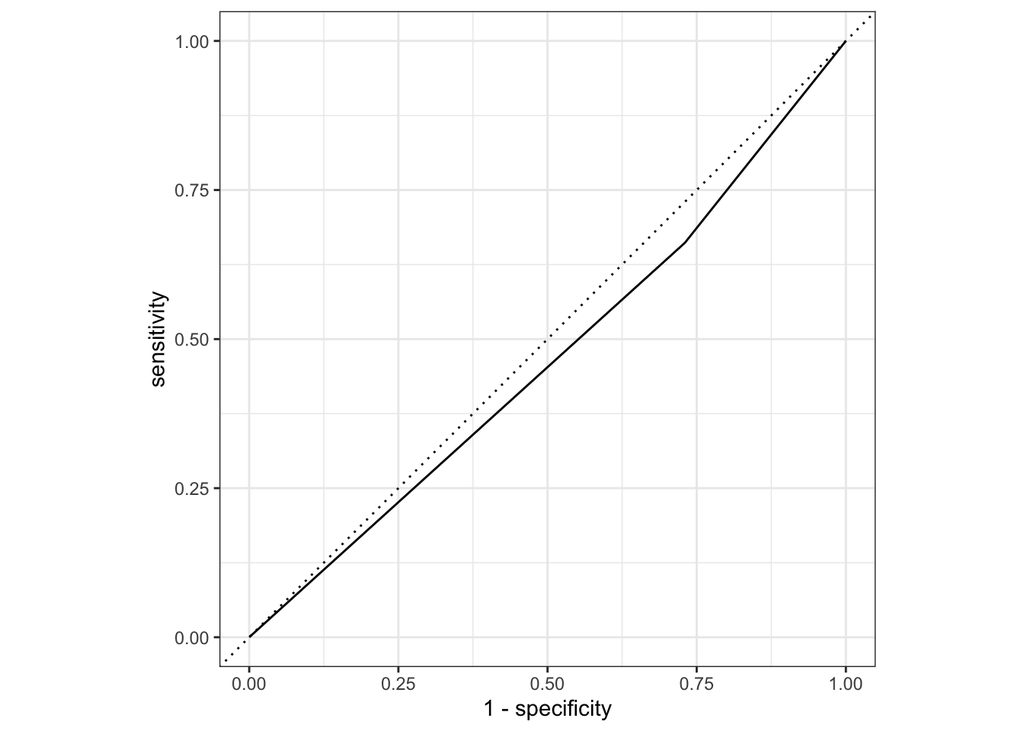

```r
Nausea_augment_predict3 %>%
  roc_curve(truth = Nausea, .pred_Yes, event_level = "second") %>%
  autoplot()
```

```r
Nausea_augment_predict3 %>%
  roc_auc(truth = Nausea, .pred_Yes, event_level = "second")
```

```
## # A tibble: 1 × 3
##   .metric .estimator .estimate
##   <chr>   <chr>          <dbl>
## 1 roc_auc binary         0.466
```

```r
predict(Nausea_fit2, training_data)
```

```
## # A tibble: 547 × 1
##    .pred_class
##    <fct>
##  1 No
##  2 No
##  3 No
##  4 No
##  5 No
##  6 No
##  7 No
##  8 No
##  9 No
## 10 No
## # … with 537 more rows
```

```r
Nausea_augment_predict4 <-
  augment(Nausea_fit2, training_data)
```

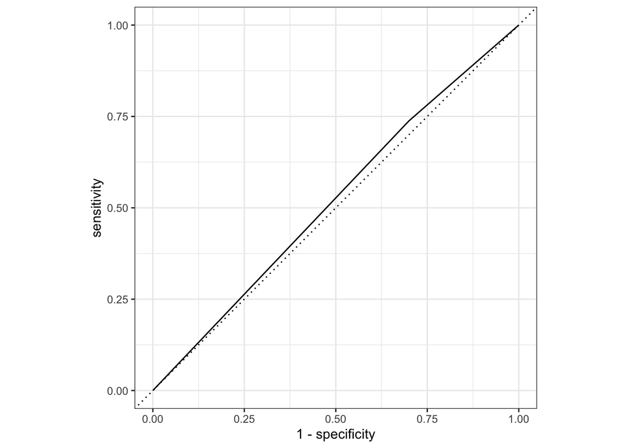

```r
Nausea_augment_predict4 %>%
  roc_curve(truth = Nausea, .pred_Yes, event_level = "second") %>%
  autoplot()
```

```r
Nausea_augment_predict4 %>%
  roc_auc(truth = Nausea, .pred_Yes, event_level = "second")
```

```
## # A tibble: 1 × 3
##   .metric .estimator .estimate
##   <chr>   <chr>          <dbl>
## 1 roc_auc binary         0.519
```

```r
all_prdtr_rec <- recipe(BodyTemp ~ ., data = training_data)
single_prdtr_rec <- recipe(BodyTemp ~ RunnyNose, data = training_data)
lm_mod <- linear_reg() %>% set_engine("lm")
```

#creating workflow

```r
BT_all_workflow <-
  workflow() %>%
  add_model(lm_mod) %>%
  add_recipe(all_prdtr_rec)
```

#model fitting to training data

```r
BT_all_fit <-
  BT_all_workflow %>%
  fit(data = training_data)
```

#applying oit to make some predictions on test data

```r
predict(BT_all_fit, test_data)
```

```
## # A tibble: 183 × 1
##    .pred
##    <dbl>
##  1  99.3
##  2  99.0
##  3  99.7
##  4  98.7
##  5  99.0
##  6  99.5
##  7  99.3
##  8  98.9
##  9  99.6
## 10  98.8
## # … with 173 more rows
```

#more prediction using augment.

```r
body_temp_predict <-
  augment(BT_all_fit, test_data)
body_temp_predict %>% select(BodyTemp,.pred)
```

```
## # A tibble: 183 × 2
##    BodyTemp .pred
##       <dbl> <dbl>
##  1     98.3  99.3
##  2     98.8  99.0
##  3    102.   99.7
##  4     98.2  98.7
##  5     97.8  99.0
##  6     97.8  99.5
##  7    100    99.3
##  8    101.   98.9
##  9     98.8  99.6
## 10    100.   98.8
## # … with 173 more rows
```

#evaluate rmse to see how good it fits the data

```r
body_temp_predict %>%
  rmse(truth = BodyTemp, .pred)
```

```
## # A tibble: 1 × 3
##   .metric .estimator .estimate
##   <chr>   <chr>          <dbl>
## 1 rmse    standard        1.15
```

#creating workflow

```r
BT_single_workflow <-
  workflow() %>%
  add_model(lm_mod) %>%
  add_recipe(single_prdtr_rec)
```

#model fitting to training data

```r
BT_single_fit <-
  BT_single_workflow %>%
  fit(data = training_data)
```

#applying oit to make some predictions on test data

```r
predict(BT_single_fit, test_data)
```

```
## # A tibble: 183 × 1
##    .pred
##    <dbl>
##  1  99.1
##  2  98.9
##  3  98.9
##  4  98.9
##  5  99.1
##  6  99.1
##  7  98.9
##  8  99.1
##  9  99.1
## 10  99.1
## # … with 173 more rows
```

#more prediction using augment.

```r
body_temp_predict <-
  augment(BT_single_fit, test_data)
body_temp_predict %>% select(BodyTemp,.pred)
```

```
## # A tibble: 183 × 2
##    BodyTemp .pred
##       <dbl> <dbl>
##  1     98.3  99.1
##  2     98.8  98.9
##  3    102.   98.9
##  4     98.2  98.9
##  5     97.8  99.1
##  6     97.8  99.1
##  7    100    98.9
##  8    101.   99.1
##  9     98.8  99.1
## 10    100.   99.1
## # … with 173 more rows
```

#evaluate rmse to see how good it fits the data

```r
body_temp_predict %>%
  rmse(truth = BodyTemp, .pred)
```

```
## # A tibble: 1 × 3
##   .metric .estimator .estimate
##   <chr>   <chr>          <dbl>
## 1 rmse    standard        1.13
```

# rmse for single predictor model is 1.1x, while that for all-predictor model is also 1.1x. Therefore, all-predictor model and the single predictor model are similar in prediction accuracy.

# ###################### Below is where Zhihan’s part starts

# receipe for model with all predictors and the linear model

```r
all_prdtr_rec <- recipe(BodyTemp ~ ., data = training_data)
single_prdtr_rec <- recipe(BodyTemp ~ RunnyNose, data = training_data)
lm_mod <- linear_reg() %>% set_engine("lm")
```

#creating workflow

```r
BT_all_workflow <-
  workflow() %>%
  add_model(lm_mod) %>%
  add_recipe(all_prdtr_rec)
```

#model fitting to training data

```r
BT_all_fit <-
  BT_all_workflow %>%
  fit(data = training_data)
```

#applying oit to make some predictions on test data

```r
predict(BT_all_fit, test_data)
```

```
## # A tibble: 183 × 1
##    .pred
##    <dbl>
##  1  99.3
##  2  99.0
##  3  99.7
##  4  98.7
##  5  99.0
##  6  99.5
##  7  99.3
##  8  98.9
##  9  99.6
## 10  98.8
## # … with 173 more rows
```

#more prediction using augment.

```r
body_temp_predict <-
  augment(BT_all_fit, test_data)
body_temp_predict %>% select(BodyTemp,.pred)
```

```
## # A tibble: 183 × 2
##    BodyTemp .pred
##       <dbl> <dbl>
##  1     98.3  99.3
##  2     98.8  99.0
##  3    102.   99.7
##  4     98.2  98.7
##  5     97.8  99.0
##  6     97.8  99.5
##  7    100    99.3
##  8    101.   98.9
##  9     98.8  99.6
## 10    100.   98.8
## # … with 173 more rows
```

#evaluate rmse to see how good it fits the data

```r
body_temp_predict %>%
  rmse(truth = BodyTemp, .pred)
```

```
## # A tibble: 1 × 3
##   .metric .estimator .estimate
##   <chr>   <chr>          <dbl>
## 1 rmse    standard        1.15
```

#creating workflow

```r
BT_single_workflow <-
  workflow() %>%
  add_model(lm_mod) %>%
  add_recipe(single_prdtr_rec)
```

#model fitting to training data

```r
BT_single_fit <-
  BT_single_workflow %>%
  fit(data = training_data)
```

#applying oit to make some predictions on test data

```r
predict(BT_single_fit, test_data)
```

```
## # A tibble: 183 × 1
##    .pred
##    <dbl>
##  1  99.1
##  2  98.9
##  3  98.9
##  4  98.9
##  5  99.1
##  6  99.1
##  7  98.9
##  8  99.1
##  9  99.1
## 10  99.1
## # … with 173 more rows
```

#more prediction using augment.

```r
body_temp_predict <-
  augment(BT_single_fit, test_data)
body_temp_predict %>% select(BodyTemp,.pred)
```

```
## # A tibble: 183 × 2
##    BodyTemp .pred
##       <dbl> <dbl>
##  1     98.3  99.1
##  2     98.8  98.9
##  3    102.   98.9
##  4     98.2  98.9
##  5     97.8  99.1
##  6     97.8  99.1
##  7    100    98.9
##  8    101.   99.1
##  9     98.8  99.1
## 10    100.   99.1
## # … with 173 more rows
```

#evaluate rmse to see how good it fits the data

```r
body_temp_predict %>%
  rmse(truth = BodyTemp, .pred)
```

```
## # A tibble: 1 × 3
##   .metric .estimator .estimate
##   <chr>   <chr>          <dbl>
## 1 rmse    standard        1.13
```

# rmse for single predictor model is 1.1x, while that for all-predictor model is also 1.1x. Therefore, all-predictor model and the single predictor model are similar in prediction accuracy.